# Medical Insurance Prices — Exploratory Data Analysis

Marcin Górski

2026-01-15

## Data Overview

```r
medins <- read.csv("D:/Studia/WdAD/EDA/medical-charges.csv")

medins$sex          <- as.factor(medins$sex)
medins$smoker       <- as.factor(medins$smoker)
medins$region       <- as.factor(medins$region)

head(medins, 3)
```

```
##   age    sex   bmi children smoker    region   charges
## 1  19 female 27.90        0    yes southwest 16884.924
## 2  18   male 33.77        1     no southeast  1725.552
## 3  28   male 33.00        3     no southeast  4449.462
```

```r
tail(medins, 3)
```

```
##      age    sex   bmi children smoker    region   charges
## 1336  18 female 36.85        0     no southeast  1629.833
## 1337  21 female 25.80        0     no southwest  2007.945
## 1338  61 female 29.07        0    yes northwest 29141.360
```

```r
str(medins)
```

```
## 'data.frame':    1338 obs. of  7 variables:
##  $ age     : int  19 18 28 33 32 31 46 37 37 60 ...
##  $ sex     : Factor w/ 2 levels "female","male": 1 2 2 2 2 1 1 1 2 1 ...
##  $ bmi     : num  27.9 33.8 33 22.7 28.9 ...
##  $ children: int  0 1 3 0 0 0 1 3 2 0 ...
##  $ smoker  : Factor w/ 2 levels "no","yes": 2 1 1 1 1 1 1 1 1 1 ...
##  $ region  : Factor w/ 4 levels "northeast","northwest",..: 4 3 3 2 2 3 3 2 1 2 ...
##  $ charges : num  16885 1726 4449 21984 3867 ...
```

```r
psych::describe(medins)
```

```
##          vars    n     mean       sd  median  trimmed     mad     min      max
## age         1 1338    39.21    14.05   39.00    39.01   17.79   18.00    64.00
## sex*        2 1338     1.51     0.50    2.00     1.51    0.00    1.00     2.00
## bmi         3 1338    30.66     6.10   30.40    30.50    6.20   15.96    53.13
## children    4 1338     1.09     1.21    1.00     0.94    1.48    0.00     5.00
## smoker*     5 1338     1.20     0.40    1.00     1.13    0.00    1.00     2.00
## region*     6 1338     2.52     1.10    3.00     2.52    1.48    1.00     4.00
## charges     7 1338 13270.42 12110.01 9382.03 11076.02 7440.81 1121.87 63770.43
##             range  skew kurtosis     se
## age         46.00  0.06    -1.25   0.38
## sex*         1.00 -0.02    -2.00   0.01
## bmi         37.17  0.28    -0.06   0.17
## children     5.00  0.94     0.19   0.03
## smoker*      1.00  1.46     0.14   0.01
## region*      3.00 -0.04    -1.33   0.03
## charges  62648.55  1.51     1.59 331.07
```

The dataset contains **1338 observations** across **7 variables** describing individual medical insurance charges. Predictors include:

- **Numeric:** age, BMI, number of children
- **Categorical:** sex, smoker status, region

The goal of this analysis is to explore how each of these characteristics relates to insurance charges.

## Missing Values

```r
md.pattern(medins, rotate.names = TRUE)
```

```
##  /\     /\
## {  `---'  }
## {  O   O  }
## ==>  V <==  No need for mice. This data set is completely observed.
##  \  \|/  /
##   `-----'
```

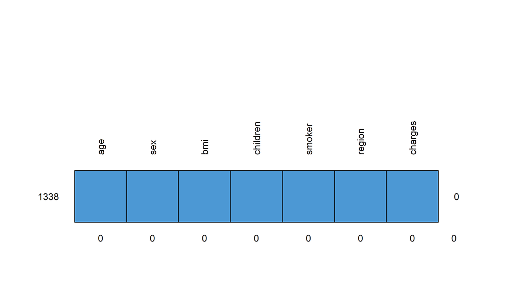

```
##      age sex bmi children smoker region charges
## 1338   1   1   1        1      1      1       1 0
##        0   0   0        0      0      0       0 0
```

No missing values are present in any column — the dataset is complete.

## Variable Distributions

### Categorical Variables

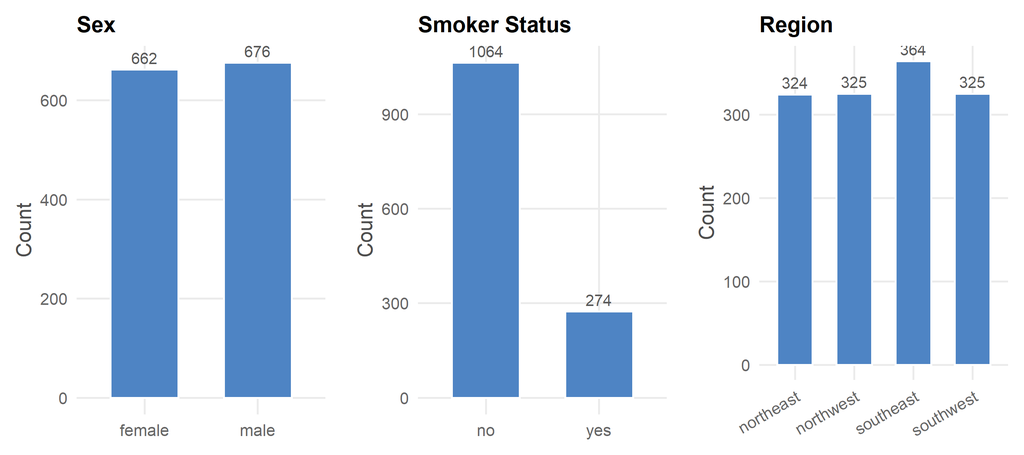

```r
plot_bar_cat <- function(data, var, title, pal = PAL_BLUE) {
  ggplot(data, aes(x = .data[[var]])) +
    geom_bar(fill = pal, color = "white", width = 0.6) +
    geom_text(stat = "count",
              aes(label = after_stat(count)),
              vjust = -0.5, color = "grey35", size = 3.5) +
    labs(title = title, x = NULL, y = "Count") +
    theme_eda
}

grid.arrange(
  plot_bar_cat(medins, "sex",    "Sex"),
  plot_bar_cat(medins, "smoker", "Smoker Status"),
  plot_bar_cat(medins, "region", "Region") +
    theme(axis.text.x = element_text(angle = 30, hjust = 1)),
  nrow = 1
)
```

```r
table(medins[, c("sex", "smoker")])
```

```
##         smoker
## sex       no yes
##   female 547 115
##   male   517 159
```

Sex and region are well balanced. Smokers are a clear minority, though not so rare as to be edge cases. Among smokers, males are slightly more represented: **23.52%** of men smoke versus **17.37%** of women. Whether this difference is statistically significant will be tested later.

### Numeric Variables

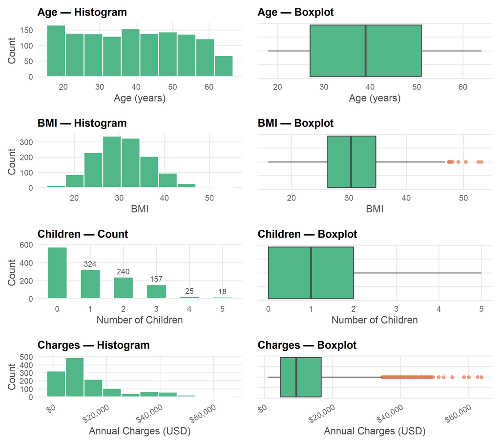

```r
p_age_hist <- ggplot(medins, aes(x = age)) +
  geom_histogram(bins = 10, fill = PAL_GREEN, color = "white") +
  labs(title = "Age — Histogram", x = "Age (years)", y = "Count") +
  theme_eda

p_age_box <- ggplot(medins, aes(x = age)) +
  geom_boxplot(fill = PAL_GREEN, color = "grey30",
               outlier.color = PAL_ORANGE, outlier.alpha = 0.7) +
  labs(title = "Age — Boxplot", x = "Age (years)") +
  theme_eda +
  theme(axis.text.y = element_blank(), axis.ticks.y = element_blank())

p_bmi_hist <- ggplot(medins, aes(x = bmi)) +
  geom_histogram(bins = 10, fill = PAL_GREEN, color = "white") +
  labs(title = "BMI — Histogram", x = "BMI", y = "Count") +
  theme_eda

p_bmi_box <- ggplot(medins, aes(x = bmi)) +
  geom_boxplot(fill = PAL_GREEN, color = "grey30",
               outlier.color = PAL_ORANGE, outlier.alpha = 0.7) +
  labs(title = "BMI — Boxplot", x = "BMI") +
  theme_eda +
  theme(axis.text.y = element_blank(), axis.ticks.y = element_blank())

p_ch_bar <- ggplot(medins, aes(x = factor(children))) +
  geom_bar(fill = PAL_GREEN, color = "white", width = 0.6) +
  geom_text(stat = "count", aes(label = after_stat(count)),
            vjust = -0.5, color = "grey35", size = 3.5) +
  labs(title = "Children — Count", x = "Number of Children", y = "Count") +
  theme_eda

p_ch_box <- ggplot(medins, aes(x = children)) +
  geom_boxplot(fill = PAL_GREEN, color = "grey30",
               outlier.color = PAL_ORANGE, outlier.alpha = 0.7) +
  labs(title = "Children — Boxplot", x = "Number of Children") +
  theme_eda +
  theme(axis.text.y = element_blank(), axis.ticks.y = element_blank())

p_chg_hist <- ggplot(medins, aes(x = charges)) +
  geom_histogram(bins = 10, fill = PAL_GREEN, color = "white") +
  scale_x_continuous(labels = scales::dollar_format()) +
  labs(title = "Charges — Histogram", x = "Annual Charges (USD)", y = "Count") +
  theme_eda +
  theme(axis.text.x = element_text(angle = 30, hjust = 1))

p_chg_box <- ggplot(medins, aes(x = charges)) +
  geom_boxplot(fill = PAL_GREEN, color = "grey30",
               outlier.color = PAL_ORANGE, outlier.alpha = 0.7) +
  scale_x_continuous(labels = scales::dollar_format()) +
  labs(title = "Charges — Boxplot", x = "Annual Charges (USD)") +
  theme_eda +
  theme(axis.text.y = element_blank(), axis.ticks.y = element_blank(),
        axis.text.x = element_text(angle = 30, hjust = 1))

grid.arrange(
  p_age_hist, p_age_box,
  p_bmi_hist, p_bmi_box,
  p_ch_bar,   p_ch_box,
  p_chg_hist, p_chg_box,
  nrow = 4, ncol = 2
)
```

```r
cat("Age:\n");      quantile(medins$age,      probs = c(0, .01, .25, .5, .75, .95, .99, 1))
```

```
## Age:
```

```
##   0%   1%  25%  50%  75%  95%  99% 100%
##   18   18   27   39   51   62   64   64
```

```r
cat("\nBMI:\n");    quantile(medins$bmi,      probs = c(0, .01, .25, .5, .75, .95, .99, 1))
```

```
##
## BMI:
```

```
##       0%       1%      25%      50%      75%      95%      99%     100%
## 15.96000 17.89515 26.29625 30.40000 34.69375 41.10600 46.40790 53.13000
```

```r
cat("\nChildren:\n");quantile(medins$children, probs = c(0, .01, .25, .5, .75, .95, .99, 1))
```

```
##
## Children:
```

```
##   0%   1%  25%  50%  75%  95%  99% 100%
##    0    0    0    1    2    3    5    5
```

```r
cat("\nCharges:\n"); quantile(medins$charges,  probs = c(0, .01, .25, .5, .75, .95, .99, 1))
```

```
##
## Charges:
```

```
##        0%        1%       25%       50%       75%       95%       99%      100%
##  1121.874  1252.973  4740.287  9382.033 16639.913 41181.828 48537.481 63770.428
```

- **Age** is approximately uniformly distributed with no outliers.
- **BMI** is roughly normal with a few high-end outliers; fewer than 5% of individuals exceed a BMI of 41.
- **Children** is strongly right-skewed — only 5% have more than 3 children; the maximum is 5.
- **Charges** are also right-skewed with notable outliers. Only 1% pay above ~$48,500, while the maximum reaches nearly $64,000.

### Correlation Matrix

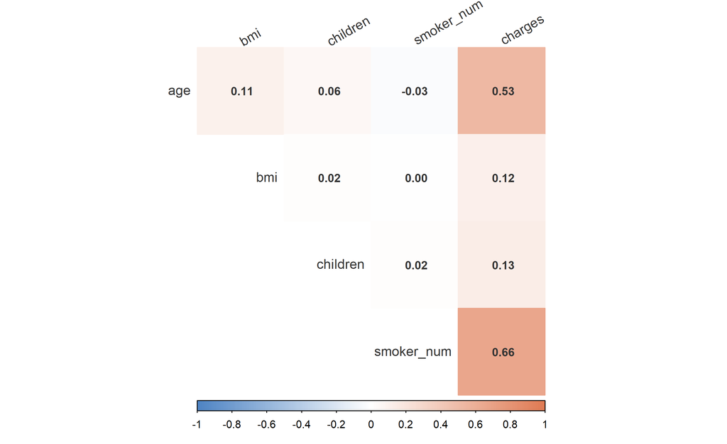

```r
medins$smoker_num <- as.numeric(medins$smoker)

cor_matrix <- cor(
  medins[, c("age", "bmi", "children", "smoker_num", "charges")],
  method = "spearman"
)

corrplot(cor_matrix,
         method      = "color",
         type        = "upper",
         addCoef.col = "grey20",
         number.cex  = 0.85,
         tl.col      = "grey20",
         tl.srt      = 30,
         col         = colorRampPalette(c(PAL_BLUE, "white", PAL_ORANGE))(200),
         diag        = FALSE,
         cl.pos      = "b")
```

# Exploring Relationships

## BMI

To examine the relationship between body mass and other variables, I add a new column `bmi_category`: **Low** (BMI < 18.5), **Normal**, and **High** (BMI > 30, i.e. obese).

```r
medins$bmi_category <- factor(
  ifelse(medins$bmi < 18.5, "Low",
         ifelse(medins$bmi <= 30, "Normal", "High")),
  levels = c("Low", "Normal", "High")
)
```

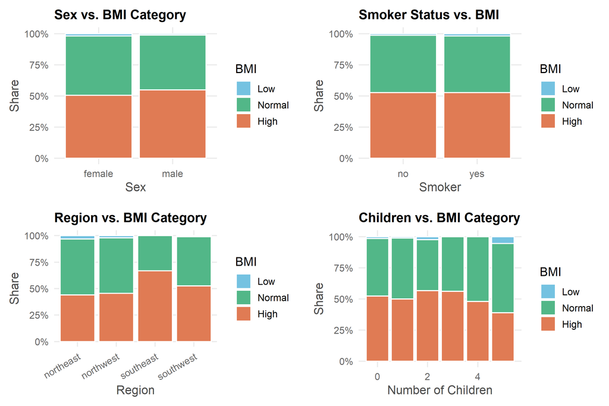

```r
plot_fill_bar <- function(data, x_var, title, x_lab) {
  ggplot(data, aes(x = .data[[x_var]], fill = bmi_category)) +
    geom_bar(color = "white", position = "fill") +
    scale_fill_manual(values = PAL_BMI) +
    scale_y_continuous(labels = scales::percent_format()) +
    labs(title = title, x = x_lab, y = "Share", fill = "BMI") +
    theme_eda
}

grid.arrange(
  plot_fill_bar(medins, "sex",    "Sex vs. BMI Category",      "Sex"),
  plot_fill_bar(medins, "smoker", "Smoker Status vs. BMI",     "Smoker"),
  plot_fill_bar(medins, "region", "Region vs. BMI Category",   "Region") +
    theme(axis.text.x = element_text(angle = 30, hjust = 1)),
  plot_fill_bar(medins, "children", "Children vs. BMI Category", "Number of Children"),
  nrow = 2, ncol = 2
)
```

The only categorical variable that visually appears to relate to BMI is **region**. I’ll verify this with a one-way ANOVA. First, checking assumptions:

```r
for (r in levels(medins$region)) {
  cat("\n--- Lilliefors test for region:", r, "---\n")
  print(
    medins %>% filter(region == r) %>% pull(bmi) %>% lillie.test()
  )
}
```

```
##
## --- Lilliefors test for region: northeast ---
##
##  Lilliefors (Kolmogorov-Smirnov) normality test
##
## data:  .
## D = 0.036625, p-value = 0.3618
##
##
## --- Lilliefors test for region: northwest ---
##
##  Lilliefors (Kolmogorov-Smirnov) normality test
##
## data:  .
## D = 0.026358, p-value = 0.8426
##
##
## --- Lilliefors test for region: southeast ---
##
##  Lilliefors (Kolmogorov-Smirnov) normality test
##
## data:  .
## D = 0.036843, p-value = 0.2679
##
##
## --- Lilliefors test for region: southwest ---
##
##  Lilliefors (Kolmogorov-Smirnov) normality test
##
## data:  .
## D = 0.029848, p-value = 0.6858
```

The Lilliefors test (preferred over Shapiro-Wilk for large samples) finds no evidence against normality of BMI in any region. Now checking homogeneity of variance:

```r
test_bartlett <- bartlett.test(bmi ~ region, data = medins)
test_bartlett
```

```
##
##  Bartlett test of homogeneity of variances
##
## data:  bmi by region
## Bartlett's K-squared = 18.742, df = 3, p-value = 0.0003091
```

```r
oneway.test(bmi ~ region, data = medins)
```

```
##
##  One-way analysis of means (not assuming equal variances)
##
## data:  bmi and region
## F = 35.834, num df = 3.00, denom df = 739.54, p-value < 2.2e-16
```

The p-value is very small, so I move to post-hoc testing with the **Games-Howell test**:

```r
gamesHowellTest(bmi ~ region, data = na.omit(medins[, c("bmi", "region")]))
```

```
##           northeast northwest southeast
## northwest 0.9999    -         -
## southeast < 2e-16   < 2e-16   -
## southwest 0.0103    0.0059    2.3e-08
```

The results confirm the pattern visible in the chart. Individuals from the **Southeast** have a significantly different BMI from all other regions, and the **Southwest** also differs significantly from both northern regions. The direction is clear from the stacked bar chart — the Southeast has the highest proportion of obese individuals, the Southwest is intermediate, and northern regions have the most people in the normal BMI range (and a higher share of underweight individuals).

## Smoker Status vs. Sex

Returning to the earlier question — is the higher smoking rate among men statistically significant? I’ll use a one-sided two-proportion test. Sample sizes are more than adequate, and the empirical proportions (~17% and ~23%) are well within the usable range.

```r
wektor_palacy <- medins %>%
  count(sex, smoker) %>%
  filter(smoker == "yes") %>%
  pull(n)

wektor_plcie <- medins %>%
  count(sex) %>%
  pull(n)

odsetek_palacych <- prop.test(x = wektor_palacy, n = wektor_plcie, alternative = "less")
odsetek_palacych
```

```
##
##  2-sample test for equality of proportions with continuity correction
##
## data:  wektor_palacy out of wektor_plcie
## X-squared = 7.3929, df = 1, p-value = 0.003274
## alternative hypothesis: less
## 95 percent confidence interval:
##  -1.00000000 -0.02384949
## sample estimates:
##    prop 1    prop 2
## 0.1737160 0.2352071
```

The test confirms that **the proportion of smokers is significantly higher among men** (p = 0.0033).

## Smoker Status vs. Age

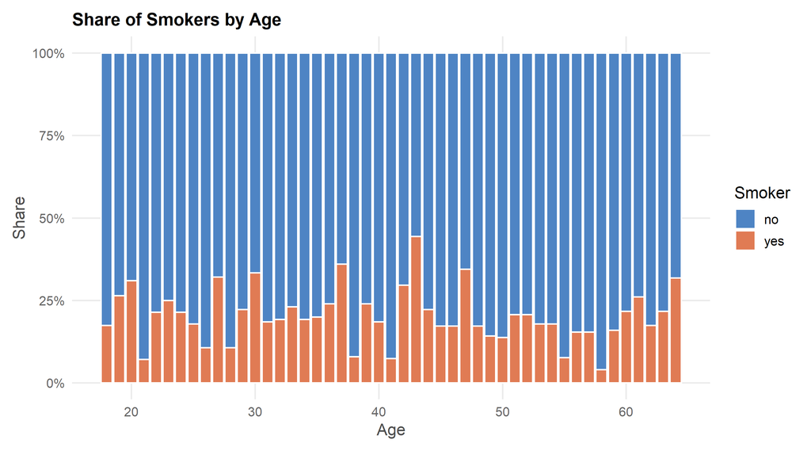

```r
ggplot(medins, aes(x = age, fill = smoker)) +
  geom_bar(color = "white", position = "fill") +
  scale_fill_manual(values = PAL_SMOKE) +
  scale_y_continuous(labels = scales::percent_format()) +
  labs(title = "Share of Smokers by Age",
       x = "Age", y = "Share", fill = "Smoker") +
  theme_eda
```

The correlation matrix showed no relationship between smoking and age, and this 100% stacked bar chart confirms it. While the proportion approaches 50% for some middle-aged groups, no consistent trend is visible.

## Smoker Status vs. BMI

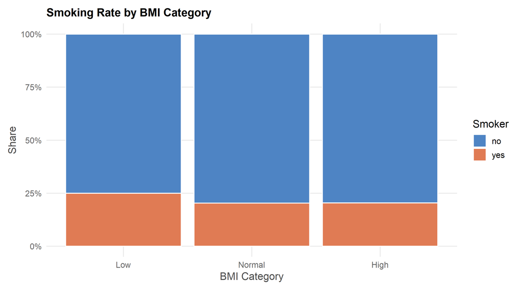

```r
ggplot(medins, aes(x = bmi_category, fill = smoker)) +
  geom_bar(color = "white", position = "fill") +
  scale_fill_manual(values = PAL_SMOKE) +
  scale_y_continuous(labels = scales::percent_format()) +
  labs(title = "Smoking Rate by BMI Category",
       x = "BMI Category", y = "Share", fill = "Smoker") +
  theme_eda
```

Visually, the Low BMI group appears to have the highest smoking rate. However, let’s check the counts:

```r
medins %>% filter(bmi_category == "Low")  %>% count(smoker)
```

```
##   smoker  n
## 1     no 15
## 2    yes  5
```

```r
medins %>% filter(bmi_category == "High") %>% count(smoker)
```

```
##   smoker   n
## 1     no 561
## 2    yes 144
```

Only 20 individuals fall in the Low category — too few for a reliable asymptotic test. I’ll compare **Normal vs. High** instead:

```r
palacze_bmi <- medins %>%
  count(bmi_category, smoker) %>%
  filter(bmi_category %in% c("Normal", "High"), smoker == "yes") %>%
  pull(n)

lacznie_bmi <- medins %>%
  count(bmi_category) %>%
  filter(bmi_category %in% c("Normal", "High")) %>%
  pull(n)

odsetek_bmi <- prop.test(x = palacze_bmi, n = lacznie_bmi, alternative = "greater")
odsetek_bmi
```

```
##
##  2-sample test for equality of proportions with continuity correction
##
## data:  palacze_bmi out of lacznie_bmi
## X-squared = 8.7473e-30, df = 1, p-value = 0.5
## alternative hypothesis: greater
## 95 percent confidence interval:
##  -0.03728946  1.00000000
## sample estimates:
##    prop 1    prop 2
## 0.2039152 0.2042553
```

## Smoker Status vs. Number of Children

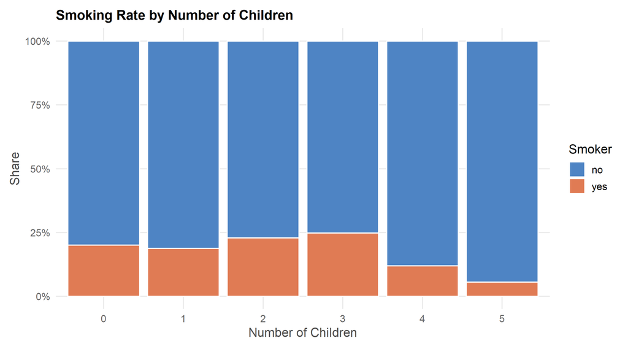

```r
ggplot(medins, aes(x = factor(children), fill = smoker)) +
  geom_bar(color = "white", position = "fill") +
  scale_fill_manual(values = PAL_SMOKE) +
  scale_y_continuous(labels = scales::percent_format()) +
  labs(title = "Smoking Rate by Number of Children",
       x = "Number of Children", y = "Share", fill = "Smoker") +
  theme_eda
```

The lowest smoking share appears in the 4–5 children group, but those groups are very small. No meaningful trend is evident here.

# What Drives Insurance Charges?

## Age vs. Charges

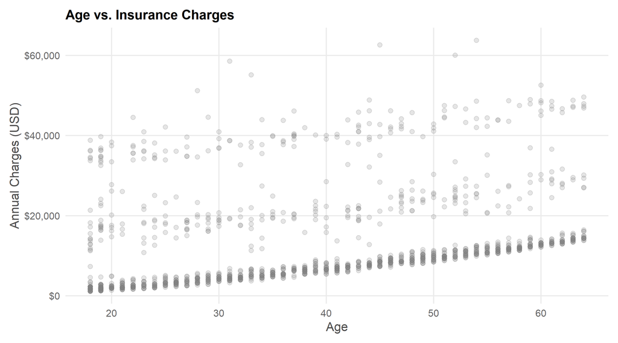

```r
ggplot(medins, aes(x = age, y = charges)) +
  geom_point(size = 2, color = "grey50", alpha = 0.2) +
  scale_y_continuous(labels = scales::dollar_format()) +
  labs(title = "Age vs. Insurance Charges",
       x = "Age", y = "Annual Charges (USD)") +
  theme_eda
```

The scatter plot reveals a near-linear trend at the bottom, but for each age a substantial group pays far higher premiums. These outlying points also form two less distinct upward bands. Smoker status is likely a key factor.

## Age + Smoker Status vs. Charges

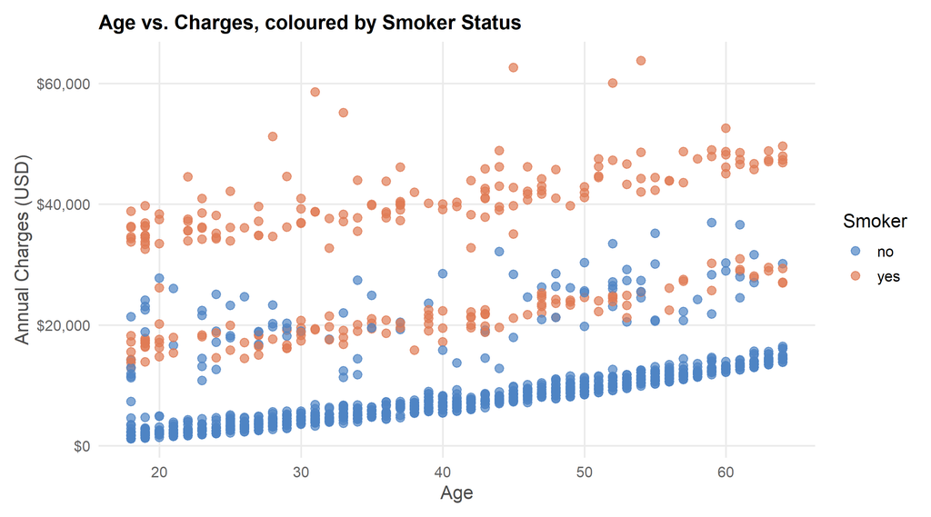

```r
ggplot(medins, aes(x = age, y = charges, color = smoker)) +
  geom_point(size = 2.5, alpha = 0.7) +
  scale_color_manual(values = PAL_SMOKE) +
  scale_y_continuous(labels = scales::dollar_format()) +
  labs(title = "Age vs. Charges, coloured by Smoker Status",
       x = "Age", y = "Annual Charges (USD)", color = "Smoker") +
  theme_eda
```

The theory holds. The bottom band is exclusively **non-smokers**, and the top band is almost exclusively **smokers**. A middle band contains a mix of both. Can BMI explain this middle group?

## Age + Smoker Status + BMI vs. Charges

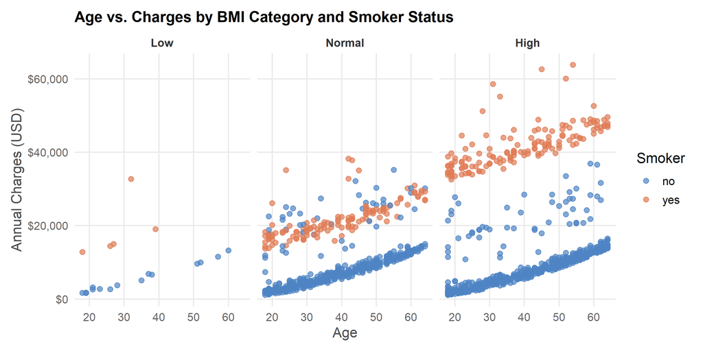

```r
ggplot(medins, aes(x = age, y = charges, color = smoker)) +
  geom_point(size = 2, alpha = 0.7) +
  scale_color_manual(values = PAL_SMOKE) +
  scale_y_continuous(labels = scales::dollar_format()) +
  facet_wrap(~bmi_category, ncol = 3) +
  labs(title = "Age vs. Charges by BMI Category and Smoker Status",
       x = "Age", y = "Annual Charges (USD)", color = "Smoker") +
  theme_eda
```

This sheds further light on the structure. Smokers with **normal BMI** tend to fall in the middle band, while **obese smokers** dominate the top band — and all non-smokers remain in the lower- and middle bands. This suggests that obesity and smoking may interact multiplicatively in pricing.

```r
medins %>% group_by(smoker, bmi_category) %>% count()
```

```
## # A tibble: 6 × 3
## # Groups:   smoker, bmi_category [6]
##   smoker bmi_category     n
##   <fct>  <fct>        <int>
## 1 no     Low             15
## 2 no     Normal         488
## 3 no     High           561
## 4 yes    Low              5
## 5 yes    Normal         125
## 6 yes    High           144
```

```r
tapply(
  medins$charges[medins$bmi_category == "Low"],
  medins$smoker[medins$bmi_category == "Low"],
  lillie.test
)
```

```
## $no
##
##  Lilliefors (Kolmogorov-Smirnov) normality test
##
## data:  X[[i]]
## D = 0.21128, p-value = 0.07028
##
##
## $yes
##
##  Lilliefors (Kolmogorov-Smirnov) normality test
##
## data:  X[[i]]
## D = 0.2895, p-value = 0.1822
```

```r
leveneTest(charges ~ smoker * bmi_category, data = medins)
```

```
## Levene's Test for Homogeneity of Variance (center = median)
##         Df F value Pr(>F)
## group    5  1.2314 0.2919
##       1332
```

## Number of Children vs. Charges

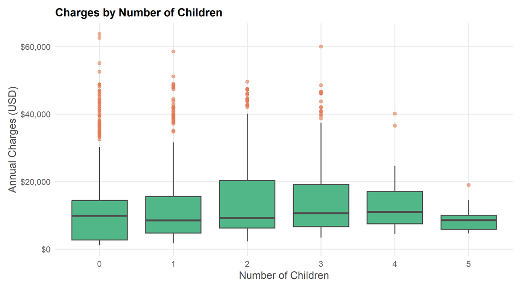

```r
ggplot(medins, aes(x = as.factor(children), y = charges)) +
  geom_boxplot(fill = PAL_GREEN, color = "grey30",
               outlier.color = PAL_ORANGE, outlier.alpha = 0.6) +
  scale_y_continuous(labels = scales::dollar_format()) +
  labs(title = "Charges by Number of Children",
       x = "Number of Children", y = "Annual Charges (USD)") +
  theme_eda
```

Medians are similar across groups, though boxes for higher child counts sit slightly higher. The notably low median for 5 children is unsurprising given only 18 such observations exist.

## Region vs. Charges

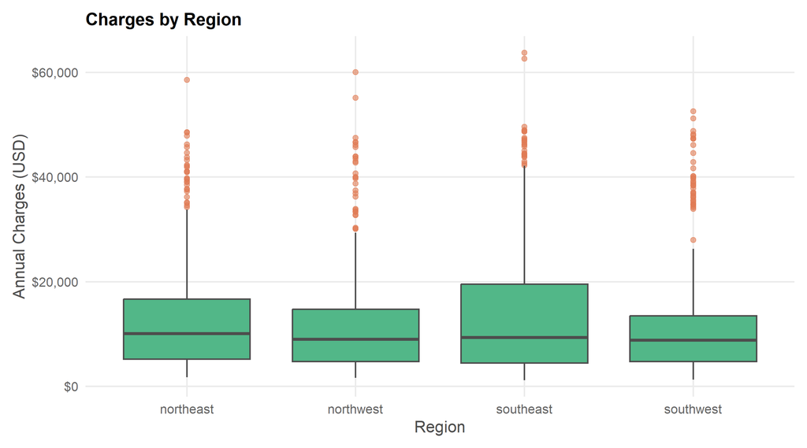

```r
ggplot(medins, aes(x = region, y = charges)) +
  geom_boxplot(fill = PAL_GREEN, color = "grey30",
               outlier.color = PAL_ORANGE, outlier.alpha = 0.6) +
  scale_y_continuous(labels = scales::dollar_format()) +
  labs(title = "Charges by Region",
       x = "Region", y = "Annual Charges (USD)") +
  theme_eda
```

The Southeast box reaches the highest, but recall that this region also has the highest obesity rate — so the elevated charges are likely driven by BMI rather than region per se.

## Sex vs. Charges

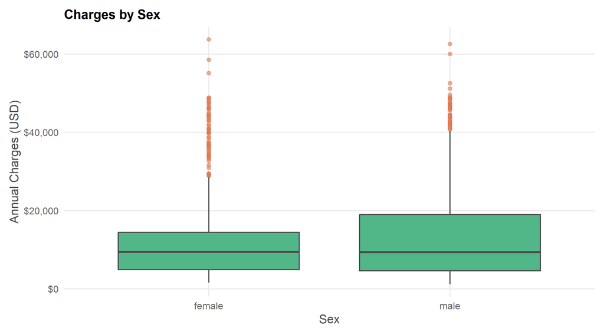

```r
ggplot(medins, aes(x = sex, y = charges)) +
  geom_boxplot(fill = PAL_GREEN, color = "grey30",
               outlier.color = PAL_ORANGE, outlier.alpha = 0.6) +
  scale_y_continuous(labels = scales::dollar_format()) +
  labs(title = "Charges by Sex",
       x = "Sex", y = "Annual Charges (USD)") +
  theme_eda
```

Medians are nearly identical; differences appear only in the extreme values, which is consistent with men having a higher smoking rate. To confirm, I test for a difference formally:

```r
medins %>% filter(sex == "female") %>% pull(charges) %>% lillie.test()
```

```
##
##  Lilliefors (Kolmogorov-Smirnov) normality test
##
## data:  .
## D = 0.1843, p-value < 2.2e-16
```

```r
medins %>% filter(sex == "male")   %>% pull(charges) %>% lillie.test()
```

```
##
##  Lilliefors (Kolmogorov-Smirnov) normality test
##
## data:  .
## D = 0.19806, p-value < 2.2e-16
```

Lilliefors rejects normality for both groups, so I use the non-parametric **Wilcoxon rank-sum test**:

```r
wilcox.test(charges ~ sex, data = medins)
```

```
##
##  Wilcoxon rank sum test with continuity correction
##
## data:  charges by sex
## W = 221304, p-value = 0.7287
## alternative hypothesis: true location shift is not equal to 0
```

No significant difference in charges between sexes is found.

# Linear Models

First, let me verify whether a finer BMI split (adding an overweight category) helps explain the middle band:

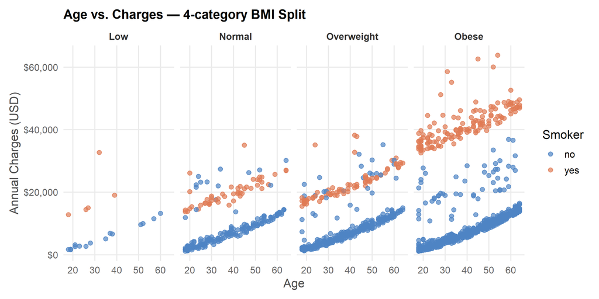

```r
medins$bmi_category4 <- factor(
  ifelse(medins$bmi < 18.5, "Low",
         ifelse(medins$bmi <= 25, "Normal",
                ifelse(medins$bmi <= 30, "Overweight", "Obese"))),
  levels = c("Low", "Normal", "Overweight", "Obese")
)

ggplot(medins, aes(x = age, y = charges, color = smoker)) +
  geom_point(size = 2, alpha = 0.7) +
  scale_color_manual(values = PAL_SMOKE) +
  scale_y_continuous(labels = scales::dollar_format()) +
  facet_wrap(~bmi_category4, ncol = 4) +
  labs(title = "Age vs. Charges — 4-category BMI Split",
       x = "Age", y = "Annual Charges (USD)", color = "Smoker") +
  theme_eda
```

The Normal and Overweight panels look nearly identical. The 3-category split was not a mistake — lets revert to it:

```r
medins$bmi_category <- factor(
  ifelse(medins$bmi < 18.5, "Low",
         ifelse(medins$bmi <= 30, "Normal", "High")),
  levels = c("Low", "Normal", "High")
)
```

Also, one other possibility investigated before modelling — do any remaining variables (sex, region, children) explain the middle-band membership?

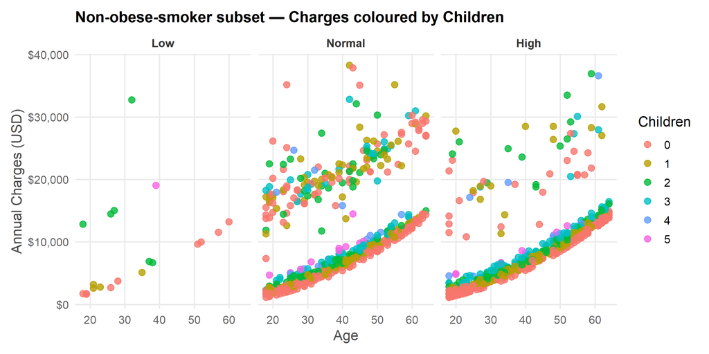

```r
medins %>%
  filter(bmi_category %in% c("Low", "Normal") | (bmi_category == "High" & smoker == "no")) %>%
  ggplot(aes(x = age, y = charges, color = factor(children))) +
  geom_point(size = 2.5, alpha = 0.8) +
  scale_y_continuous(labels = scales::dollar_format()) +
  facet_wrap(~bmi_category, ncol = 3) +
  labs(title = "Non-obese-smoker subset — Charges coloured by Children",
       x = "Age", y = "Annual Charges (USD)", color = "Children") +
  theme_eda
```

```r
grupa1 <- medins %>% filter(bmi_category == "High" & smoker == "yes")
grupa2 <- medins %>% filter(bmi_category != "High" & smoker == "yes")
grupa3 <- medins %>% filter(smoker == "no")
```

## Group 1: Obese Smokers

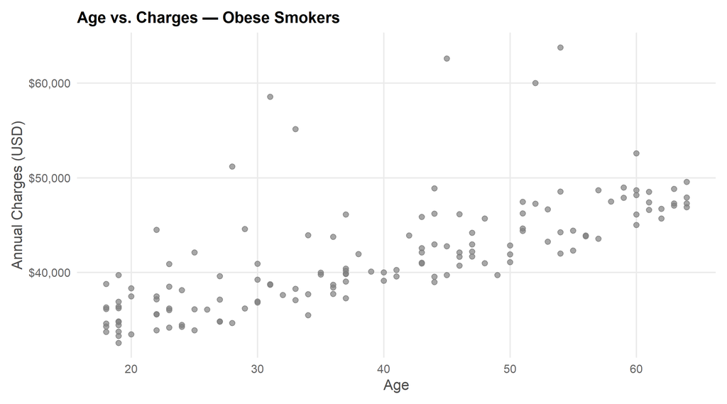

```r
ggplot(grupa1, aes(x = age, y = charges)) +
  geom_point(size = 2, color = "grey50", alpha = 0.7) +
  scale_y_continuous(labels = scales::dollar_format()) +
  labs(title = "Age vs. Charges — Obese Smokers",
       x = "Age", y = "Annual Charges (USD)") +
  theme_eda
```

The trend is nearly perfect apart from six high outliers. Let’s inspect them:

```r
grupa1 %>% filter(charges > 50000 & age < 55) %>% arrange(age)
```

```
##   age    sex    bmi children smoker    region  charges smoker_num bmi_category
## 1  28   male 36.400        1    yes southwest 51194.56          2         High
## 2  31 female 38.095        1    yes northeast 58571.07          2         High
## 3  33 female 35.530        0    yes northwest 55135.40          2         High
## 4  45   male 30.360        0    yes southeast 62592.87          2         High
## 5  52   male 34.485        3    yes northwest 60021.40          2         High
## 6  54 female 47.410        0    yes southeast 63770.43          2         High
##   bmi_category4
## 1         Obese
## 2         Obese
## 3         Obese
## 4         Obese
## 5         Obese
## 6         Obese
```

```r
cat("\nGroup 1 mean BMI:", round(mean(grupa1$bmi), 2))
```

```
##
## Group 1 mean BMI: 35.54
```

The outliers do not share any obvious characteristic — only one has a markedly elevated BMI. These appear to be individually priced policies for reasons outside the dataset. I exclude them before modelling:

```r
grupa1_clean <- grupa1 %>% filter(charges < 50000 | age > 55)

model_gr1 <- lm(charges ~ age, data = grupa1_clean)
summary(model_gr1)
```

```
##
## Call:
## lm(formula = charges ~ age, data = grupa1_clean)
##
## Residuals:
##     Min      1Q  Median      3Q     Max
## -4072.9 -1653.1  -545.4  1319.3  8257.0
##
## Coefficients:
##             Estimate Std. Error t value Pr(>|t|)
## (Intercept) 30157.44     579.83   52.01   <2e-16 ***
## age           276.68      13.93   19.87   <2e-16 ***
## ---
## Signif. codes:  0 '***' 0.001 '**' 0.01 '*' 0.05 '.' 0.1 ' ' 1
##
## Residual standard error: 2365 on 136 degrees of freedom
## Multiple R-squared:  0.7437, Adjusted R-squared:  0.7418
## F-statistic: 394.7 on 1 and 136 DF,  p-value: < 2.2e-16
```

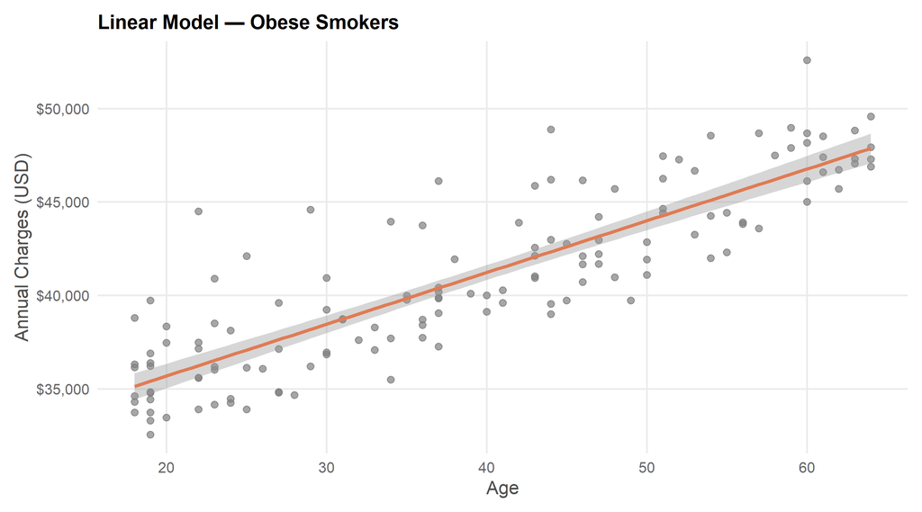

```r
ggplot(grupa1_clean, aes(x = age, y = charges)) +
  geom_point(size = 2, color = "grey50", alpha = 0.7) +
  geom_smooth(method = "lm", color = PAL_ORANGE, formula = y ~ x, se = TRUE) +
  scale_y_continuous(labels = scales::dollar_format()) +
  labs(title = "Linear Model — Obese Smokers",
       x = "Age", y = "Annual Charges (USD)") +
  theme_eda
```

```r
reszty1 <- residuals(model_gr1)
shapiro.test(reszty1)
```

```
##
##  Shapiro-Wilk normality test
##
## data:  reszty1
## W = 0.94362, p-value = 2.206e-05
```

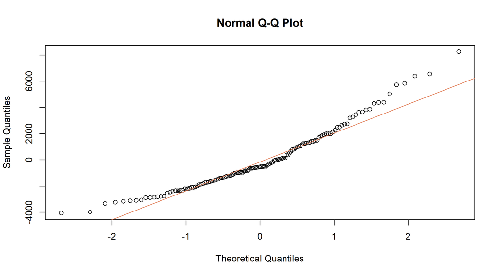

```r
qqnorm(reszty1); qqline(reszty1, col = PAL_ORANGE)
```

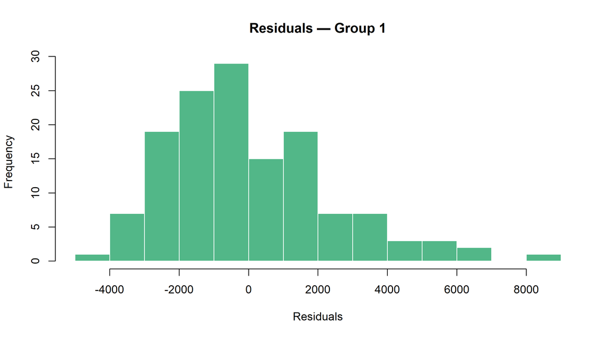

```r
hist(reszty1, col = PAL_GREEN, border = "white",
     main = "Residuals — Group 1", xlab = "Residuals")
```

Age alone explains **74.37%** of charge variance in this group. Residuals are not perfectly normal (right tail visible), so the model is more useful as a trend visualiser than a precise predictor.

## Group 2: Non-obese Smokers

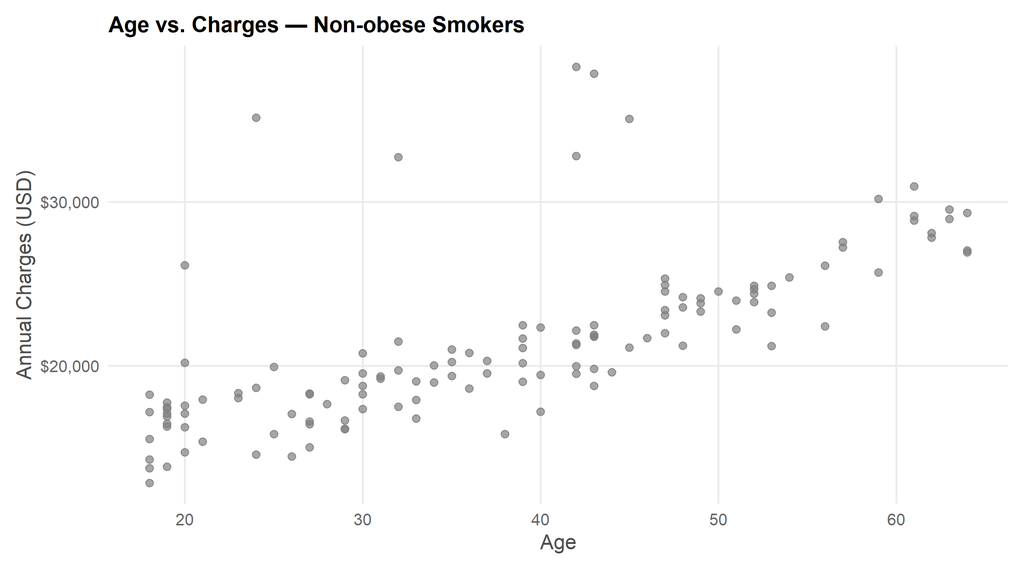

```r
ggplot(grupa2, aes(x = age, y = charges)) +
  geom_point(size = 2, color = "grey50", alpha = 0.7) +
  scale_y_continuous(labels = scales::dollar_format()) +
  labs(title = "Age vs. Charges — Non-obese Smokers",
       x = "Age", y = "Annual Charges (USD)") +
  theme_eda
```

The structure mirrors Group 1, with ~7 outliers. Inspecting them:

```r
grupa2 %>%
  filter((charges > 25000 & age < 40) | (charges > 30000 & age < 55)) %>%
  arrange(age)
```

```
##   age    sex    bmi children smoker    region  charges smoker_num bmi_category
## 1  20 female 24.420        0    yes southeast 26125.67          2       Normal
## 2  24   male 28.500        0    yes northeast 35147.53          2       Normal
## 3  32 female 17.765        2    yes northwest 32734.19          2          Low
## 4  42   male 26.070        1    yes southeast 38245.59          2       Normal
## 5  42   male 28.310        3    yes northwest 32787.46          2       Normal
## 6  43   male 27.800        0    yes southwest 37829.72          2       Normal
## 7  45   male 22.895        0    yes northeast 35069.37          2       Normal
##   bmi_category4
## 1        Normal
## 2    Overweight
## 3           Low
## 4    Overweight
## 5    Overweight
## 6    Overweight
## 7        Normal
```

```r
cat("\nGroup 2 mean BMI:", round(mean(grupa2$bmi), 2))
```

```
##
## Group 2 mean BMI: 25.35
```

Again, no shared characteristic. Excluding and modelling:

```r
grupa2_clean <- grupa2 %>%
  filter(charges < 25000 | (charges < 30000 & age > 40) | age > 55)

model_gr2 <- lm(charges ~ age, data = grupa2_clean)
summary(model_gr2)
```

```
##
## Call:
## lm(formula = charges ~ age, data = grupa2_clean)
##
## Residuals:
##     Min      1Q  Median      3Q     Max
## -4830.2 -1131.4   179.6  1142.2  4387.4
##
## Coefficients:
##             Estimate Std. Error t value Pr(>|t|)
## (Intercept) 10367.74     454.60   22.81   <2e-16 ***
## age           270.61      11.27   24.02   <2e-16 ***
## ---
## Signif. codes:  0 '***' 0.001 '**' 0.01 '*' 0.05 '.' 0.1 ' ' 1
##
## Residual standard error: 1696 on 121 degrees of freedom
## Multiple R-squared:  0.8266, Adjusted R-squared:  0.8252
## F-statistic:   577 on 1 and 121 DF,  p-value: < 2.2e-16
```

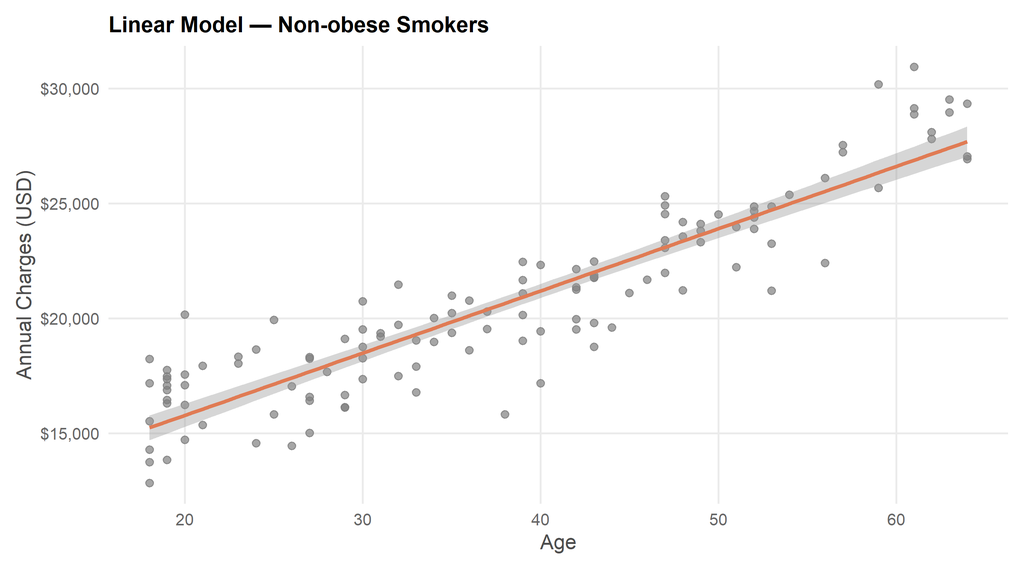

```r
ggplot(grupa2_clean, aes(x = age, y = charges)) +
  geom_point(size = 2, color = "grey50", alpha = 0.7) +
  geom_smooth(method = "lm", color = PAL_ORANGE, formula = y ~ x, se = TRUE) +
  scale_y_continuous(labels = scales::dollar_format()) +
  labs(title = "Linear Model — Non-obese Smokers",
       x = "Age", y = "Annual Charges (USD)") +
  theme_eda
```

```r
reszty2 <- residuals(model_gr2)
shapiro.test(reszty2)
```

```
##
##  Shapiro-Wilk normality test
##
## data:  reszty2
## W = 0.99387, p-value = 0.8725
```

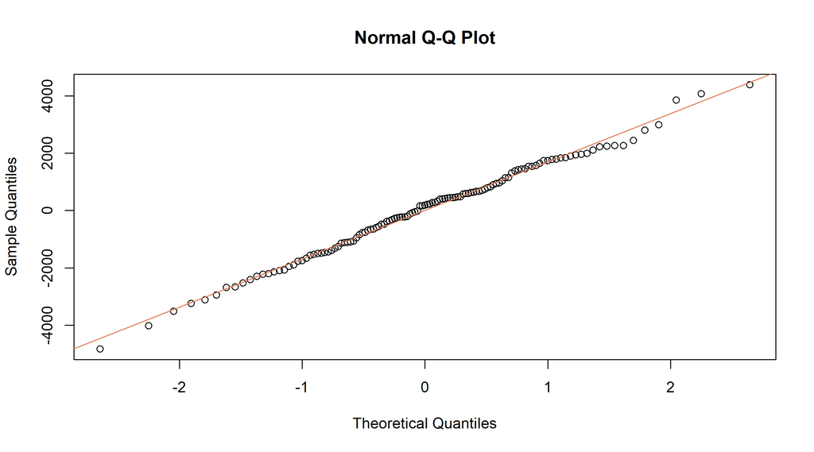

```r
qqnorm(reszty2); qqline(reszty2, col = PAL_ORANGE)
```

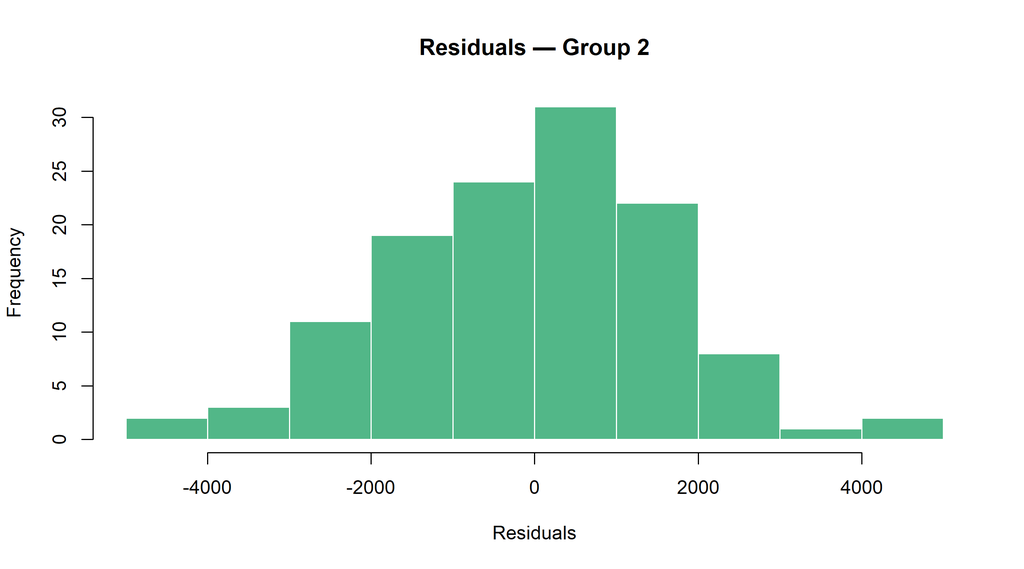

```r
hist(reszty2, col = PAL_GREEN, border = "white",
     main = "Residuals — Group 2", xlab = "Residuals")
```

Model 2 performs even better, explaining **82.66%** of variance, and Shapiro-Wilk does not reject normality of residuals. Provided a person can be confidently classified outside the outlier cluster, this model could be used for prediction.

## Group 3: Non-smokers

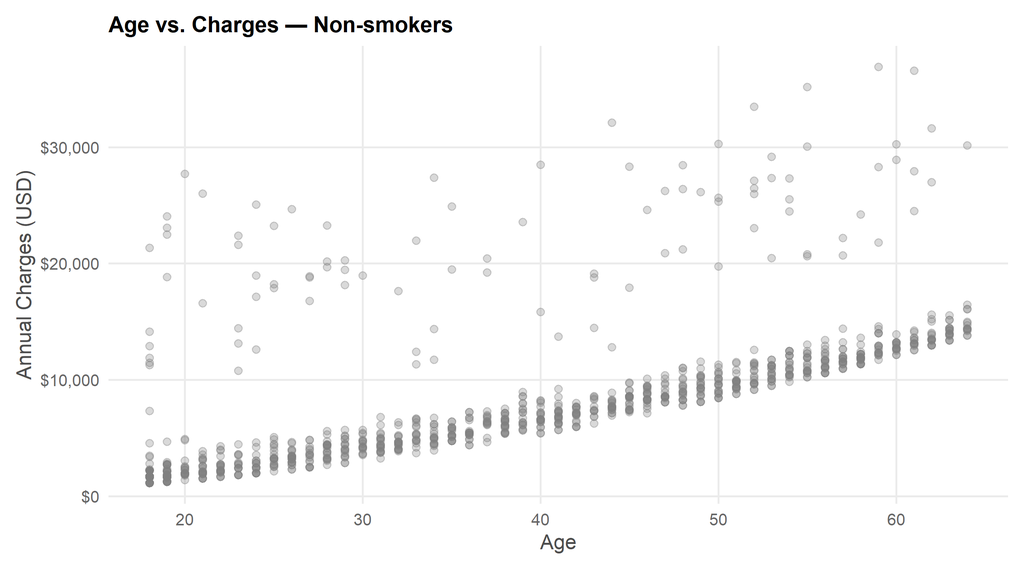

```r
ggplot(grupa3, aes(x = age, y = charges)) +
  geom_point(size = 2, color = "grey50", alpha = 0.3) +
  scale_y_continuous(labels = scales::dollar_format()) +
  labs(title = "Age vs. Charges — Non-smokers",
       x = "Age", y = "Annual Charges (USD)") +
  theme_eda
```

The non-smoker scatter shows a very tight, slightly convex trend at the bottom. The regularity of point alignment may reflect that the insurer records age with monthly precision while the dataset stores only integer years. Points above this dense band likely reflect individually assessed risks — chronic conditions, family history — that are absent from the dataset.

# Conclusions

The analysis leaves little doubt about the primary drivers of insurance charges: **age, smoker status, and obesity**. The data naturally cluster around three pricing bands, and no variable in the dataset explains membership in the intermediate band, suggesting that unobserved factors — such as chronic illness or family medical history — account for the variance there.